# Krótki tutorial do pakietu OpenPoland

Kamil Wais

Aktualizacja: Wed Oct 01 11:34:57 2014

Wersja tutoriala: 2.0

Strona domowa pakietu R’a: http://www.wais.kamil.rzeszow.pl/openpoland

Repozytorium GitHub: https://github.com/kalimu/openPoland

## Opis pakietu

Dzięki pakietowi `openPoland` możliwy jest szybki i bezpośredni dostęp z poziomu R’a do bazy otwartych danych udostępnionych poprzez API [OpenPoland.net](http://openPoland.net).

## Instalowanie pakietu

### Stabilna wersja z CRAN

Obecnie jeszcze niedostępne. Zobacz poniżej jak możesz zainstalować wersję bespośrednio z repozytorium GitHuba.

### Wersja deweloperska z GitHub’a

Żeby instalować pakiety z GitHub’a musisz mieć najpierw zainstalowany pakiet `devtools`.

```r
# install.packages('devtools')
auth_token = 'bfce48a2c16ed7eb4505f9143efaa1e238160443'
devtools::install_github("kalimu/openPoland", auth_token=auth_token)
```

## Zarejestruj się i pobierz indywidualny token

Żeby korzystać z API musisz się zarejestrować. Otrzymasz wtedy token, który pozwoli na autoryzację dostępu. Rejestracja jest banalna i zajmuje krótką chwilę: https://openpoland.net/signup/.

```r
token = "[tutaj wklej swój token]"
```

## Przykładowe wykorzystanie pakietu

Najpierw pamiętaj, aby ustalić polską lokalizację w R’ze (jeśli pracujesz w innej). To pozowli na prawidłowe wyświetlanie i wyszukiwanie polskich “ogonków” w tytułach zbiorów.

```r
Sys.setlocale("LC_ALL", "Polish")
```

```
## [1] "LC_COLLATE=Polish_Poland.1250;LC_CTYPE=Polish_Poland.1250;LC_MONETARY=Polish_Poland.1250;LC_NUMERIC=C;LC_TIME=Polish_Poland.1250"
```

Ładujemy pakiet…

```r
library(openPoland)
```

Załóżmy, że jesteśmy zainteresowani chronionymi gatunkami zwierząt w Polsce.  
Poszukajmy zbioru danych, który byłby z tym związany…

```r
openPolandSearch(query = "zwierz")
```

```
##
 Downloaded pages: 1
##  Done!
##  19 datasets found from the query: 'zwierz'.
```

```
##       id
##  1: 1879
##  2: 1914
##  3: 2097
##  4: 2100
##  5: 2118
##  6: 2071
##  7: 2088
##  8: 3033
##  9: 3028
## 10: 3035
## 11: 3037
## 12: 3029
## 13: 1981
## 14: 2307
```

[output cut: 25 more lines]

```r
openPolandSearch(query = "zwierz", subQuery = "chro")
```

```
##
 Downloaded pages: 1
##  Done!
##  19 datasets found from the query: 'zwierz'.
```

```
##      id                                             title
## 1: 1981 Ważniejsze zwierzęta chronione (NTS-2, 2003-2012)
```

```r
id = 1981
```

Jest zbiór o identyfikatorze `1981` ma tytuł “Ważniejsze zwierzęta chronione”. Sprawdźmy metadane czy znajdziemy tam te informacje o które nam chodzi…

```r
openPolandMeta(id =  1981, token = token)
```

```
##
## Dataset id: 1981
## Dataset title: Ważniejsze zwierzęta chronione (NTS-2, 2003-2012)
##
## Years: 2003 2004 2005 2006 2007 2008 2009 2010 2011 2012
##
## Zwierzęta
##     id         name
## 1 4212        żubry
## 2 4213       kozice
## 3 4214 niedźwiedzie
## 4 4215        bobry
## 5 4216        rysie
## 6 4217        wilki
```

W metadanych znajdujemy kilka ważnych informacji. Nasz zbiór o identyfikatorze `1981` zawiera dane z lat od 2003 do 2012 roku, dotyczące 6 gatunków: żubrów, kozic, niedźwiedzi, bobrów, rysiów i wilków. Poziom NTS-2 oznacza, że dane są dostępne w podziale na regiony i województwa Polski.

Załóżmy, że chcemy zobaczyć jak zmieniała się liczba zwięrząt w poszczególnych latach.

Ściągnijmy cały zbiór danych…

```r
data = openPolandData(id =  1981, token = token)
```

```
##
 Downloaded pages: 1
 Downloaded pages: 2
 Downloaded pages: 3
##  Done!
```

Załadujmy dodatkowe, przydatne pakiety…

```r
library(dplyr)
```

```r
library(ggplot2)
library(stringr)
library(pander)
```

Zobaczmy jak zmienia się liczebność bobrów przez te lata…

```r
tab =
        as.data.frame(data) %>%
        filter(str_detect(string = nts, pattern = "[0-9][0]{9,9}") ) %>%
        group_by('year', 'dim1')%>% summarize(sum=sum(value)) %>%
        filter(dim1 %in% c("bobry"))

pander(tab)
```

| year | dim1 | sum |
| --- | --- | --- |
| 2003 | bobry | 39453 |
| 2004 | bobry | 41823 |
| 2005 | bobry | 43499 |
| 2006 | bobry | 49040 |
| 2007 | bobry | 51334 |
| 2008 | bobry | 58847 |
| 2009 | bobry | 64254 |
| 2010 | bobry | 68993 |
| 2011 | bobry | 78174 |
| 2012 | bobry | 88974 |

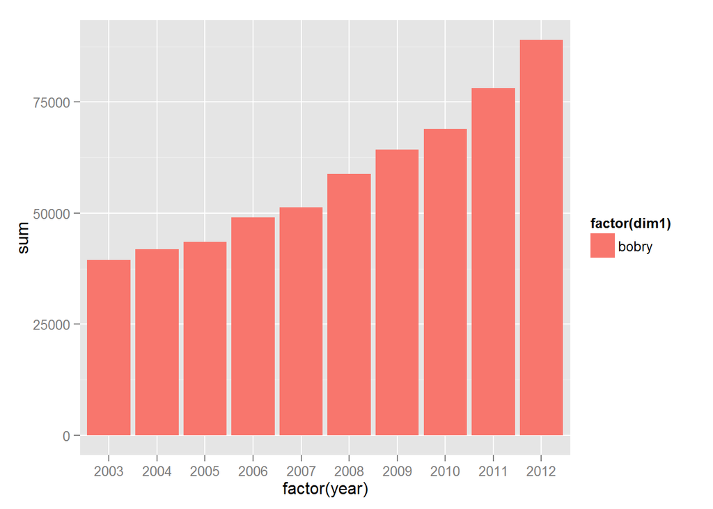

```r
ggplot(tab,aes(x=factor(year),y=sum, fill = factor(dim1))) +
geom_bar(stat="identity",position="dodge")
```

Bobry rosną w siłę.

Teraz niedźwiedzie, kozice i rysie…

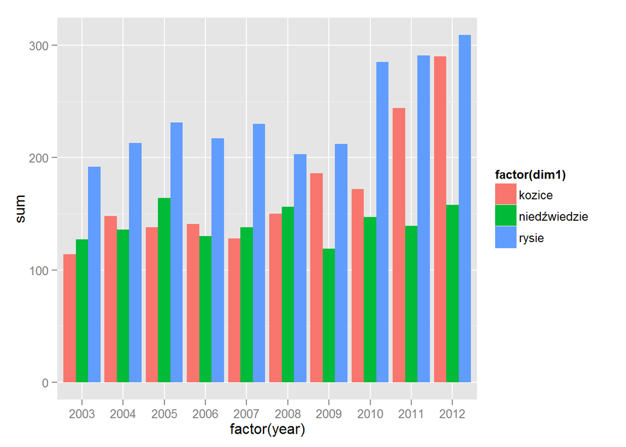

```r
tab =
        as.data.frame(data) %>%
        filter(str_detect(string = nts, pattern = "[0-9][0]{9,9}") ) %>%
        group_by('year', 'dim1')%.% summarize(sum=sum(value)) %>%
        filter(dim1 %in% c("niedźwiedzie","kozice", "rysie"))

ggplot(tab,aes(x=factor(year),y=sum, fill = factor(dim1))) +
geom_bar(stat="identity",position="dodge")
```

Kozice i rysie idą w górę, niedźwiedzie nie za bardzo.

To jeszcze sprwadźmy jak się trzymają wilki i żubry…

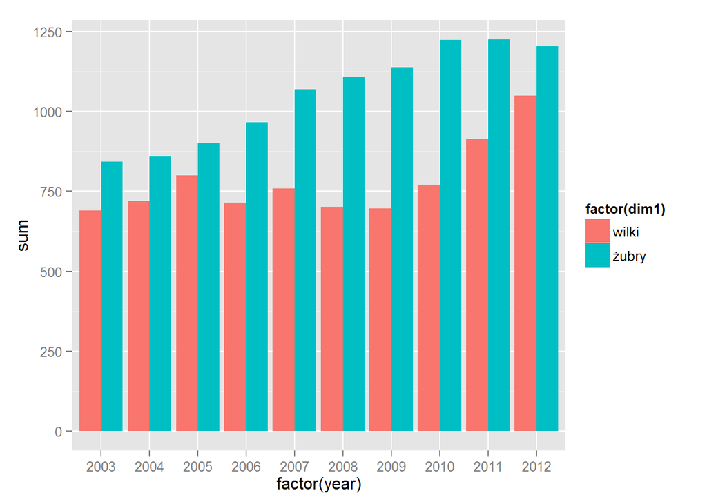

```r
tab =
        as.data.frame(data) %>%
        filter(str_detect(string = nts, pattern = "[0-9][0]{9,9}") ) %>%
        group_by('year', 'dim1')%.% summarize(sum=sum(value)) %>%
        filter(dim1 %in% c("wilki", "żubry"))

ggplot(tab,aes(x=factor(year),y=sum, fill = factor(dim1))) +
geom_bar(stat="identity",position="dodge")
```

Wilkom się polepszyło w ostatnich latach, żubrom spadło.

To jeszcze może tylko tablica z liczebnością gatunków tylko dla województwa podkarpackiego w 2012 roku, z wykorzystaniem funkcji filtrującej dane….

```r
tab = openPolandFilter(data, name="PODKARPACKIE", year=2012)
pander(tab[,c(1,2,3,4,6)])
```

| nts | name | dim1 | year | value |
| --- | --- | --- | --- | --- |
| 3180000000 | PODKARPACKIE | żubry | 2012 | 256 |
| 3180000000 | PODKARPACKIE | kozice | 2012 | 0 |
| 3180000000 | PODKARPACKIE | niedźwiedzie | 2012 | 125 |
| 3180000000 | PODKARPACKIE | bobry | 2012 | 13500 |
| 3180000000 | PODKARPACKIE | rysie | 2012 | 165 |
| 3180000000 | PODKARPACKIE | wilki | 2012 | 365 |

Na Podkarpaciu BOBRY RULEZ!

## Podsumowanie

w ten sposób można szybko i łatwo pozyskiwać różnorodne dane, które dostępne są w Polsce jako informacja publiczna - baza danych OpenPoland.net stale rośnie.

W R’ze pakiet `openPoland` udostępnia cztery podstawowe funkcje:

- `openPolandSearch()` - wyszukiwanie zbiorów danych
- `openPolandMeta()` - pozyskiwanie metadanych o zbiorach
- `openPolandData()` - pobieranie danych do R’a
- `openPolandFilter()` - filtrowanie już ściągniętego zbioru danych np. po poziomach administracyjnych lub identyfikatorach NTS

Te cztery funkcje pozwalają na bardzo ułatwiony dostęp do milionów rekordów i tysięcy zbiorów.

Miłych analiz!  
Kamil Wais